# WDATA System-Wide Trip Simulation

### *Testing whether it is possible to tap in and out of all 98 WMATA Metrorail stations in one operating day*

### The Challenge, Should You Choose to Accept It:

- Log a visit to every Metrorail station in the WMATA system in one open-to-close period. Visits will be verifiable via "trip history" on the WMATA SmarTrip app.

### The Details:

- Only Metrorail trains may be used to travel between stations (no coordinated pickups at the end of a line, no running between two adjacent stations, etc.).

### Sources and Strategy:

- The challenge will be attempted on a Friday to maximize available time. The system begins operation at 5:00 AM and runs until 1:00 AM the following day, giving challenge participants 20 hours to accomplish the feat. The last train on the Silver Line is rumored to run until 2:15 AM, but this assumption was not made in the simulation.
- Train frequencies were taken from the weekday [timetables](https://www.wmata.com/schedules/timetables/) on the WMATA website. Variation in these frequencies was un-scientifically estimated as a standard deviation of 2 minutes for frequencies under 10 minutes and 3 minutes for frequencies of 10+ minutes.
- At stations where challenge participants will (or may) transfer lines, uniform distributions with a minimum of 2 minutes and maximum of (line frequency + standard deviation) were used to estimate the time before a boardable train arrives.
- Ride times between stations were calculated using the [trip planner](https://www.wmata.com/schedules/trip-planner/) on the WMATA website. Ride times between stations were assumed to be the same in both directions.

### Planned Route:

*Legs of the trip in Green and Red may be switched.

[figure not shown]

```python
# Decide how many simulations you want to run
total_iterations = 1000000

# Enter estimates of frequencies and standard deviations for scheduled frequencies
freq_5_6 = 6
freq_6_8 = 8
freq_10_12 = 12

sd_5_6 = 2
sd_6_8 = 2
sd_10_12 = 3

# Enter estimate of minimum time spent in a station
min_time = 2
```

```python
import numpy as np
import pandas as pd
import random

trip_times = []
potomac_ave_splits = []
oranges_at_end = []
current_iterations = 0

times_at_fort_totten = []
times_at_lenfant = []
times_at_pentagon = []
times_at_lenfant2 = []
times_at_rosslyn = []
times_at_efc = []

for i in range(total_iterations):
    # Red Line Shady Grove to Glenmont and back to Fort Totten
    # 23 stations, 70 then 15 min ride time, frequency 5-6 mins
    # Don't count Shady Grove wait time since it is the starting point
    # Skip Metro Center, Gallery Place, Fort Totten
    rng = np.random.default_rng()
    red_time = sum(rng.normal(size=23)*sd_5_6 + freq_5_6) + 70 + 15
    total_time = red_time
    times_at_fort_totten.append(total_time)

    # Green Line Fort Totten to Greenbelt and back to Shaw
    # 8 stations, 13 then 22 min ride time, frequency 6-8 mins
    wait_time = np.random.uniform(low=min_time, high=freq_6_8+sd_6_8)
    green_time = sum(rng.normal(size=8)*sd_6_8 + freq_6_8) + 13 + 22
    total_time += (wait_time + green_time)


    # Green/Yellow Line Shaw to L'Enfant Plaza
    # 3 stations, 7 min ride time, frequency 6-8 mins
    # One line (whichever we're on) is normal; the other is uniform
    green_time = np.random.uniform(low=min_time, high=freq_6_8+sd_6_8, size=3)
    yellow_time = rng.normal(size=3)*sd_6_8 + freq_6_8
    fast_times = sum(np.minimum(green_time, yellow_time)) + 7
    total_time += fast_times
    times_at_lenfant.append(total_time)

    # Blue/Orange/Silver Line L'Enfant Plaza to Potomac Ave
    # 4 stations, 7 min ride time, frequency 10-12 mins
    # One line (whichever we're on) is normal; the others are uniform
    wait_time = np.random.uniform(low=min_time, high=7) ### High=7 because there are 3 lines
    blue_time = rng.normal(size=4)*sd_10_12 + freq_10_12
    orange_time = np.random.uniform(low=min_time, high=10+sd_10_12, size=4) ### Orange always 10 mins
    silver_time = np.random.uniform(low=min_time, high=freq_10_12+sd_10_12, size=4)
    fast_times = np.minimum(blue_time, orange_time)
    fast_times = sum(np.minimum(fast_times, silver_time)) + 7
    total_time += (wait_time + fast_times)

    # 1) Orange Line Potomac Ave to New Carrollton and back to Stadium-Armory
    # 2) Blue/Silver Line Stadium-Armory to Downtown Largo and back to L'Enfant Plaza
    # 1 and 2 may be switched depending on line at Potomac Ave
    potomac_fork = random.randint(1, 3)
    if potomac_fork == 1 or potomac_fork == 2:
        # Blue/Silver Line Potomac Ave to Downtown Largo and back to Stadium-Armory
        # 5 stations, 18 then 16 min ride time, frequency 10-12 mins
        # One line (whichever we're on) is normal; the other is uniform
        blue_time = np.random.uniform(low=min_time, high=freq_10_12+sd_10_12, size=5)
        silver_time = rng.normal(size=5)*sd_10_12 + freq_10_12
        corridor_time = sum(np.minimum(blue_time, silver_time)) + 18 + 16
        total_time += corridor_time
        # Orange Line Stadium-Armory to New Carrollton and back to L'Enfant Plaza
        # 5 stations, 15 then 24 min ride time, frequency 10 mins
        wait_time = np.random.uniform(low=min_time, high=10+sd_10_12)
        orange_time = sum(rng.normal(size=5)*sd_10_12 + 10) + 15 + 24
        total_time += (wait_time + orange_time)
        potomac_ave_splits.append(potomac_fork)
    else:
        # Orange line Potomac Ave to New Carrollton and back to Stadium-Armory
        # 5 stations, 17 then 15 min ride time, frequency 10 mins
        orangetime = sum(rng.normal(size=5)*sd_10_12 + 10) + 17 + 15
        total_time += orangetime
        # Blue/Silver Line Stadium-Armory to Downtown Largo and back to L'Enfant Plaza
        # 5 stations, 16 then 24 min ride time, frequency 10-12 mins
        # One line (whichever we're on) is normal; the other is uniform
        blue_wait_time = np.random.uniform(low=min_time, high=freq_10_12+sd_10_12)
        silver_wait_time = np.random.uniform(low=min_time, high=freq_10_12+sd_10_12)
        wait_time = np.minimum(blue_wait_time, silver_wait_time)
        blue_time = np.random.uniform(low=min_time, high=freq_10_12+sd_10_12, size=5)
        silver_time = rng.normal(size=5)*sd_10_12 + freq_10_12
        corridor_time = sum(np.minimum(blue_time, silver_time)) + 16 + 24
        total_time += wait_time + corridor_time
        potomac_ave_splits.append(potomac_fork)

    # Yellow Line L'Enfant Plaza to Pentagon
    # 0 stations, 5 min ride time, frequency 8 mins
    wait_time = np.random.uniform(low=min_time, high=freq_6_8+sd_6_8)
    yellow_time = wait_time + 5
    total_time += yellow_time
    times_at_pentagon.append(total_time)

    # Blue/Yellow Line Pentagon to Arlington Cemetery and back to Braddock Road
    # 4 stations, 3 then 15 min ride time, frequency 8/12 mins
    # One line (whichever we're on) is normal; the other is uniform
    blue_wait_1 = np.random.uniform(low=min_time, high=freq_10_12+sd_10_12)
    blue_wait_2 = np.random.uniform(low=min_time, high=freq_10_12+sd_10_12)
    yellow_time = np.random.uniform(low=min_time, high=freq_6_8+sd_6_8, size=4)
    blue_time = rng.normal(size=4)*sd_10_12 + freq_10_12
    fast_times = sum(np.minimum(yellow_time, blue_time)) + 3 + 15
    total_time += (blue_wait_1 + blue_wait_2 + fast_times)

    # Blue Line Braddock Road to Franconia and back to King Street
    # 2 stations, 12 then 10 min ride time, frequency 10-12 mins
    wait_time =  np.random.uniform(low=min_time, high=freq_10_12+sd_10_12)
    blue_time = sum(rng.normal(size=2)*sd_10_12 + freq_10_12) + 12 + 10
    total_time += (wait_time + blue_time)

    # Yellow Line King Street to Huntington and back to L'Enfant Plaza
    # 2 stations, 3 then 22 min ride time, frequency 6-8 mins
    wait_time = np.random.uniform(low=min_time, high=freq_6_8+sd_6_8)
    yellow_time = sum(rng.normal(size=2)*sd_6_8 + freq_6_8) + 3 + 22
    total_time += (wait_time + yellow_time)
    times_at_lenfant2.append(total_time)

    # Green Line L'Enfant Plaza to Branch Ave and back to L'Enfant Plaza
    # 8 stops, 21 then 21 min ride time, frequency 6-8 mins
    wait_time = np.random.uniform(low=min_time, high=freq_6_8+sd_6_8)
    green_time = sum(rng.normal(size=8)*sd_6_8 + freq_6_8) + 21 + 21
    total_time += (wait_time + green_time)

    # Blue/Orange/Silver Line L'Enfant Plaza to Rosslyn
    # 6 stations, 13 min ride time, frequency 10-12 mins
    # One line (whichever we're on) is normal; the others are uniform
    wait_time = np.random.uniform(low=min_time, high=7) ### High=7 because there are 3 lines
    blue_time = rng.normal(size=6)*sd_10_12 + freq_10_12
    orange_time = np.random.uniform(low=min_time, high=10+sd_10_12, size=6) ### Orange always 10 mins
    silver_time = np.random.uniform(low=min_time, high=freq_10_12+sd_10_12, size=6)
    fast_times = np.minimum(blue_time, orange_time)
    fast_times = sum(np.minimum(fast_times, silver_time)) + 13
    total_time += (wait_time + fast_times)
    times_at_rosslyn.append(total_time)

    # Orange/Silver Lines Rosslyn to East Falls Church
    # 4 stations, 12 min ride time, frequency 10-12 mins
    # One line (whichever we're on) is normal; the other is uniform
    wait_time = np.random.uniform(low=min_time, high=9) ### High=9 because there are 2 lines
    orange_time = np.random.uniform(low=min_time, high=10+sd_10_12, size=4)
    silver_time = rng.normal(size=4)*sd_10_12 + freq_10_12
    fast_times = sum(np.minimum(orange_time, silver_time)) + 12
    total_time += (wait_time + fast_times)
    times_at_efc.append(total_time)

    # Orange Line East Falls Church to Vienna and back to East Falls Church
    # 3 stations, 12 then 12 min ride time, frequency 15 mins
    # Are challenge participants on Orange Line at East Falls Church?
    orange_at_end = random.randint(0, 1)
    if orange_at_end == 0:
        wait_time = np.random.uniform(low=min_time, high=15+sd_10_12)
        orange_time = sum(rng.normal(size=3)*sd_10_12 + 15) + 12 + 12
        total_time += (wait_time + orange_time)
        oranges_at_end.append(orange_at_end)
    else:
        wait_time = 0
        orange_time = sum(rng.normal(size=3)*sd_10_12 + 15) + 12 + 12
        total_time += (wait_time + orange_time)
        oranges_at_end.append(orange_at_end)

    # Silver Line East Falls Church to Assburn
    # 10 stations, 43 min ride time, frequency 15 mins
    wait_time = np.random.uniform(low=min_time, high=15+sd_10_12)
    silver_time = sum(rng.normal(size=10)*sd_10_12 + freq_10_12) + 43
    total_time += (wait_time + silver_time)

    total_time /= 60
    trip_times.append(total_time)
    current_iterations += 1

    if current_iterations % (total_iterations*0.01) == 0 and current_iterations < (total_iterations*0.25):
        print('Finished ' + str(current_iterations) + ' iterations, master.')
    elif current_iterations % (total_iterations*0.01) == 0 and current_iterations < (total_iterations*0.5):
        print('Now completed ' + str(current_iterations) + ' iterations, sir. I hope this pleases you.')
    elif current_iterations % (total_iterations*0.01) == 0 and current_iterations < (total_iterations*0.75):
        print('WE HAVE REACHED ' + str(current_iterations) + ' ITERATIONS. SIMULATION STILL STABLE.')
    elif current_iterations % (total_iterations*0.01) == 0 and current_iterations < total_iterations:
        print('EXCEEDING ' + str(current_iterations) + ' ITERATIONS. SIMULATION ADVANCING BEYOND CONTROL.')


prop_under_20 = round((len(list(filter(lambda x: x < 20, trip_times))) / total_iterations)*100, 2)
print('IT IS DONE. ALL ' + str(current_iterations) + ' ITERATIONS HAVE BEEN RUN. IN APPROXIMATELY ' + str(prop_under_20) + '% OF POSSIBLE SCENARIOS \n YOU LOGGED ALL WMATA STATIONS IN UNDER 20 HOURS. GODSPEED.')
```

[output not shown]

[output cut: 46 more lines]

```
EXCEEDING 870000 ITERATIONS. SIMULATION ADVANCING BEYOND CONTROL.
EXCEEDING 880000 ITERATIONS. SIMULATION ADVANCING BEYOND CONTROL.
EXCEEDING 890000 ITERATIONS. SIMULATION ADVANCING BEYOND CONTROL.
EXCEEDING 900000 ITERATIONS. SIMULATION ADVANCING BEYOND CONTROL.
EXCEEDING 910000 ITERATIONS. SIMULATION ADVANCING BEYOND CONTROL.
EXCEEDING 920000 ITERATIONS. SIMULATION ADVANCING BEYOND CONTROL.
EXCEEDING 930000 ITERATIONS. SIMULATION ADVANCING BEYOND CONTROL.
EXCEEDING 940000 ITERATIONS. SIMULATION ADVANCING BEYOND CONTROL.
EXCEEDING 950000 ITERATIONS. SIMULATION ADVANCING BEYOND CONTROL.
EXCEEDING 960000 ITERATIONS. SIMULATION ADVANCING BEYOND CONTROL.
EXCEEDING 970000 ITERATIONS. SIMULATION ADVANCING BEYOND CONTROL.
EXCEEDING 980000 ITERATIONS. SIMULATION ADVANCING BEYOND CONTROL.
EXCEEDING 990000 ITERATIONS. SIMULATION ADVANCING BEYOND CONTROL.
IT IS DONE. ALL 1000000 ITERATIONS HAVE BEEN RUN. IN APPROXIMATELY 73.29% OF POSSIBLE SCENARIOS
 YOU LOGGED ALL WMATA STATIONS IN UNDER 20 HOURS. GODSPEED.
```

```python
trip_times = pd.Series(trip_times)
potomac_ave_splits = pd.Series(potomac_ave_splits)
oranges_at_end = pd.Series(oranges_at_end)

times_at_fort_totten = pd.Series(times_at_fort_totten)/60
times_at_lenfant = pd.Series(times_at_lenfant)/60
times_at_pentagon = pd.Series(times_at_pentagon)/60
times_at_lenfant2 = pd.Series(times_at_lenfant2)/60
times_at_rosslyn = pd.Series(times_at_rosslyn)/60
times_at_efc = pd.Series(times_at_efc)/60

dataframe = pd.DataFrame({'trip_time': trip_times,
                          'potomac_ave_split': potomac_ave_splits,
                          'orange_at_end': oranges_at_end,
                          'fort_totten': times_at_fort_totten,
                          'lenfant': times_at_lenfant,
                          'pentagon': times_at_pentagon,
                          'lenfant2': times_at_lenfant2,
                          'rosslyn': times_at_rosslyn,
                          'efc': times_at_efc})

dataframe.head()
```

|  | trip_time | potomac_ave_split | orange_at_end | fort_totten | lenfant | pentagon | lenfant2 | rosslyn | efc |
| --- | --- | --- | --- | --- | --- | --- | --- | --- | --- |
| 0 | 19.441837 | 3 | 1 | 3.838057 | 5.941726 | 9.260939 | 11.807381 | 14.389759 | 15.243407 |
| 1 | 20.360425 | 3 | 1 | 4.162787 | 6.301311 | 9.955040 | 12.832944 | 15.568416 | 16.292217 |
| 2 | 20.118908 | 2 | 1 | 3.952817 | 6.176878 | 9.941541 | 12.674695 | 15.587142 | 16.245609 |
| 3 | 20.264003 | 1 | 1 | 3.907275 | 6.040513 | 9.507244 | 12.302391 | 15.245404 | 16.004670 |
| 4 | 19.486305 | 1 | 1 | 3.481425 | 5.698972 | 9.622741 | 12.131546 | 14.969968 | 15.772666 |

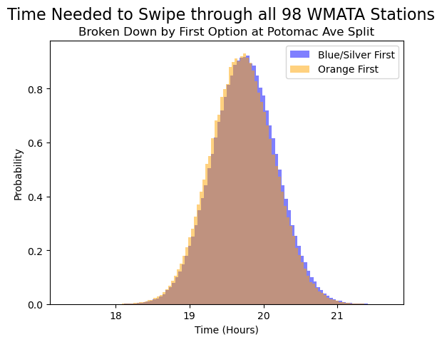

```python
import matplotlib.pyplot as plt

plt.hist(dataframe[dataframe['potomac_ave_split']<=2]['trip_time'], density=True, bins=100,
         label='Blue/Silver First', color='blue', alpha=0.5)
plt.hist(dataframe[dataframe['potomac_ave_split']>2]['trip_time'], density=True, bins=100,
         label='Orange First', color='orange', alpha=0.5)
plt.suptitle('Time Needed to Swipe through all 98 WMATA Stations', fontsize=16)
plt.title('Broken Down by First Option at Potomac Ave Split')
plt.legend(loc='upper right')
plt.xlabel('Time (Hours)')
plt.ylabel('Probability')
```

```python
blue_mean = dataframe[dataframe['potomac_ave_split']<=2]['trip_time'].mean()
orange_mean = dataframe[dataframe['potomac_ave_split']>2]['trip_time'].mean()
diff = round((blue_mean-orange_mean)*60, 2)

print('Average time when Blue/Silver Line taken first: ' + str(round(blue_mean, 3)) + ' hours')
print('Average time when Orange Line taken first: ' + str(round(orange_mean, 3)) + ' hours')
print('You save approximately ' + str(diff) + ' minutes when you take the Orange Line first at Potomac Ave.')
```

```
Average time when Blue/Silver Line taken first: 19.744 hours
Average time when Orange Line taken first: 19.707 hours
You save approximately 2.21 minutes when you take the Orange Line first at Potomac Ave.
```

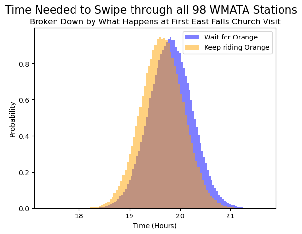

```python
plt.hist(dataframe[dataframe['orange_at_end']==0]['trip_time'], density=True, bins=100,
         label='Wait for Orange', color='blue', alpha=0.5)
plt.hist(dataframe[dataframe['orange_at_end']==1]['trip_time'], density=True, bins=100,
         label='Keep riding Orange', color='orange', alpha=0.5)
plt.suptitle('Time Needed to Swipe through all 98 WMATA Stations', fontsize=16)
plt.title('Broken Down by What Happens at First East Falls Church Visit')
plt.legend(loc='upper right')
plt.xlabel('Time (Hours)')
plt.ylabel('Probability')
```

```python
wait_mean = dataframe[dataframe['orange_at_end']==0]['trip_time'].mean()
orange_mean = dataframe[dataframe['orange_at_end']==1]['trip_time'].mean()
diff = round((wait_mean-orange_mean)*60, 2)

print('Average time when you have to wait for Orange Line: ' + str(round(wait_mean, 3)) + ' hours')
print('Average time when you are already on Orange Line: ' + str(round(orange_mean, 3)) + ' hours')
print('You save approximately ' + str(diff) + ' minutes when you are already on Orange Line at East Falls Church.')
```

```
Average time when you have to wait for Orange Line: 19.815 hours
Average time when you are already on Orange Line: 19.648 hours
You save approximately 10.01 minutes when you are already on Orange Line at East Falls Church.
```

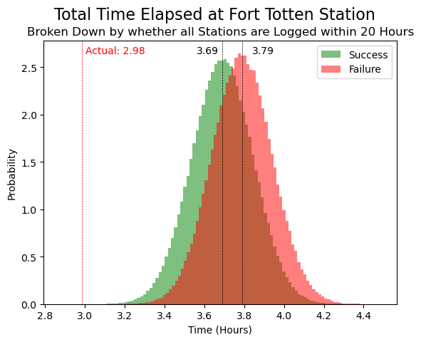

```python
success = dataframe[dataframe['trip_time']<=20]['fort_totten']
failure = dataframe[dataframe['trip_time']>20]['fort_totten']

plt.hist(success, density=True, bins=100,
         label='Success', color='green', alpha=0.5)
plt.hist(failure, density=True, bins=100,
         label='Failure', color='red', alpha=0.5)

plt.suptitle('Total Time Elapsed at Fort Totten Station', fontsize=16)
plt.title('Broken Down by whether all Stations are Logged within 20 Hours')
plt.legend(loc='upper right')
plt.xlabel('Time (Hours)')
plt.ylabel('Probability')

plt.axvline(success.mean(), color='k', linestyle='dashed', linewidth=0.5)
plt.axvline(failure.mean(), color='k', linestyle='dashed', linewidth=0.5)
min_ylim, max_ylim = plt.ylim()
plt.text(success.mean()-0.13, max_ylim*0.95, str(round(success.mean(), 2)))
plt.text(failure.mean()+0.05, max_ylim*0.95, str(round(failure.mean(), 2)))

# Post-Attempt Numbers
plt.axvline(2+59/60, color='r', linestyle='dashed', linewidth=0.5)
plt.text(2+59/60+0.02, max_ylim*0.95, 'Actual: ' + str(round(2+59/60, 2)), color='r')
```

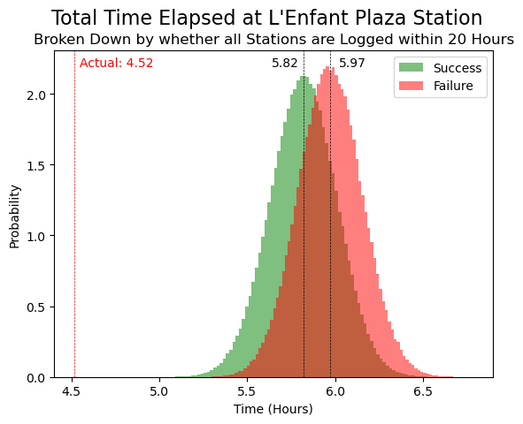

```python
success = dataframe[dataframe['trip_time']<=20]['lenfant']
failure = dataframe[dataframe['trip_time']>20]['lenfant']

plt.hist(success, density=True, bins=100,
         label='Success', color='green', alpha=0.5)
plt.hist(failure, density=True, bins=100,
         label='Failure', color='red', alpha=0.5)

plt.suptitle("Total Time Elapsed at L'Enfant Plaza Station", fontsize=16)
plt.title('Broken Down by whether all Stations are Logged within 20 Hours')
plt.legend(loc='upper right')
plt.xlabel('Time (Hours)')
plt.ylabel('Probability')

plt.axvline(success.mean(), color='k', linestyle='dashed', linewidth=0.5)
plt.axvline(failure.mean(), color='k', linestyle='dashed', linewidth=0.5)
min_ylim, max_ylim = plt.ylim()
plt.text(success.mean()-0.18, max_ylim*0.95, str(round(success.mean(), 2)))
plt.text(failure.mean()+0.05, max_ylim*0.95, str(round(failure.mean(), 2)))

# Post-Attempt Numbers
plt.axvline(4+31/60, color='r', linestyle='dashed', linewidth=0.5)
plt.text(4+31/60+0.03, max_ylim*0.95, 'Actual: ' + str(round(4+31/60, 2)), color='r')
```

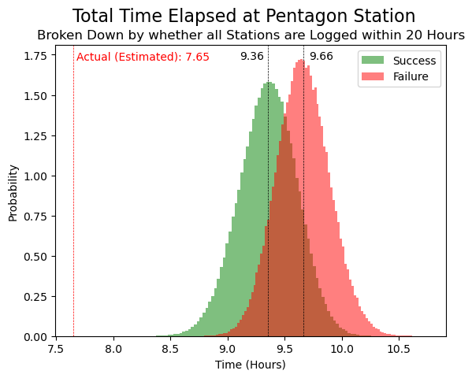

```python
success = dataframe[dataframe['trip_time']<=20]['pentagon']
failure = dataframe[dataframe['trip_time']>20]['pentagon']

plt.hist(success, density=True, bins=100,
         label='Success', color='green', alpha=0.5)
plt.hist(failure, density=True, bins=100,
         label='Failure', color='red', alpha=0.5)

plt.suptitle('Total Time Elapsed at Pentagon Station', fontsize=16)
plt.title('Broken Down by whether all Stations are Logged within 20 Hours')
plt.legend(loc='upper right')
plt.xlabel('Time (Hours)')
plt.ylabel('Probability')

plt.axvline(success.mean(), color='k', linestyle='dashed', linewidth=0.5)
plt.axvline(failure.mean(), color='k', linestyle='dashed', linewidth=0.5)
min_ylim, max_ylim = plt.ylim()
plt.text(success.mean()-0.25, max_ylim*0.95, str(round(success.mean(), 2)))
plt.text(failure.mean()+0.05, max_ylim*0.95, str(round(failure.mean(), 2)))

# Post-Attempt Numbers
plt.axvline(7+39/60, color='r', linestyle='dashed', linewidth=0.5)
plt.text(7+39/60+0.03, max_ylim*0.95, 'Actual (Estimated): ' + str(round(7+39/60, 2)), color='r')
```

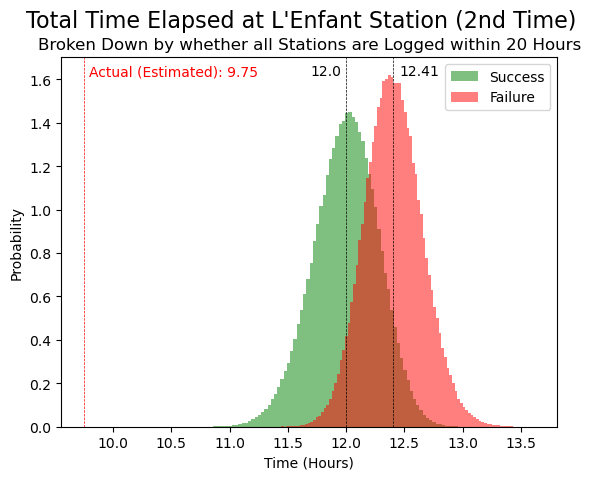

```python
success = dataframe[dataframe['trip_time']<=20]['lenfant2']
failure = dataframe[dataframe['trip_time']>20]['lenfant2']

plt.hist(success, density=True, bins=100,
         label='Success', color='green', alpha=0.5)
plt.hist(failure, density=True, bins=100,
         label='Failure', color='red', alpha=0.5)

plt.suptitle("Total Time Elapsed at L'Enfant Station (2nd Time)", fontsize=16)
plt.title('Broken Down by whether all Stations are Logged within 20 Hours')
plt.legend(loc='upper right')
plt.xlabel('Time (Hours)')
plt.ylabel('Probability')

plt.axvline(success.mean(), color='k', linestyle='dashed', linewidth=0.5)
plt.axvline(failure.mean(), color='k', linestyle='dashed', linewidth=0.5)
min_ylim, max_ylim = plt.ylim()
plt.text(success.mean()-0.3, max_ylim*0.95, str(round(success.mean(), 2)))
plt.text(failure.mean()+0.05, max_ylim*0.95, str(round(failure.mean(), 2)))

# Post-Attempt Numbers
plt.axvline(9+45/60, color='r', linestyle='dashed', linewidth=0.5)
plt.text(9+45/60+0.04, max_ylim*0.95, 'Actual (Estimated): ' + str(round(9+45/60, 2)), color='r')
```

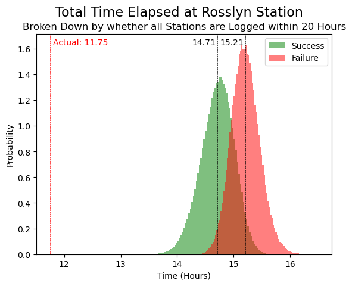

```python
success = dataframe[dataframe['trip_time']<=20]['rosslyn']
failure = dataframe[dataframe['trip_time']>20]['rosslyn']

plt.hist(success, density=True, bins=100,
         label='Success', color='green', alpha=0.5)
plt.hist(failure, density=True, bins=100,
         label='Failure', color='red', alpha=0.5)

plt.suptitle('Total Time Elapsed at Rosslyn Station', fontsize=16)
plt.title('Broken Down by whether all Stations are Logged within 20 Hours')
plt.legend(loc='upper right')
plt.xlabel('Time (Hours)')
plt.ylabel('Probability')

plt.axvline(success.mean(), color='k', linestyle='dashed', linewidth=0.5)
plt.axvline(failure.mean(), color='k', linestyle='dashed', linewidth=0.5)
min_ylim, max_ylim = plt.ylim()
plt.text(success.mean()-0.45, max_ylim*0.95, str(round(success.mean(), 2)))
plt.text(failure.mean()-0.45, max_ylim*0.95, str(round(failure.mean(), 2)))

# Post-Attempt Numbers
plt.axvline(11+45/60, color='r', linestyle='dashed', linewidth=0.5)
plt.text(11+45/60+0.05, max_ylim*0.95, 'Actual: ' + str(round(11+45/60, 2)), color='r')
```

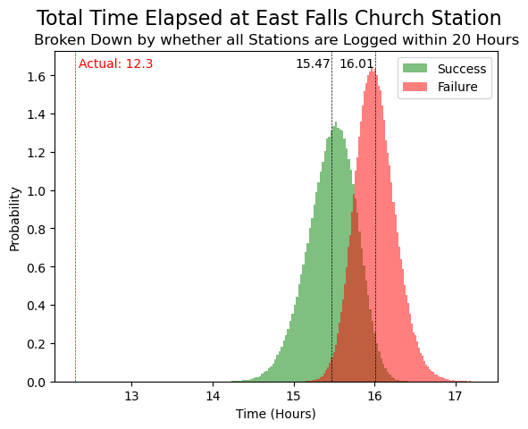

```python
success = dataframe[dataframe['trip_time']<=20]['efc']
failure = dataframe[dataframe['trip_time']>20]['efc']

plt.hist(success, density=True, bins=100,
         label='Success', color='green', alpha=0.5)
plt.hist(failure, density=True, bins=100,
         label='Failure', color='red', alpha=0.5)

plt.suptitle('Total Time Elapsed at East Falls Church Station', fontsize=16)
plt.title('Broken Down by whether all Stations are Logged within 20 Hours')
plt.legend(loc='upper right')
plt.xlabel('Time (Hours)')
plt.ylabel('Probability')

plt.axvline(success.mean(), color='k', linestyle='dashed', linewidth=0.5)
plt.axvline(failure.mean(), color='k', linestyle='dashed', linewidth=0.5)
min_ylim, max_ylim = plt.ylim()
plt.text(success.mean()-0.45, max_ylim*0.95, str(round(success.mean(), 2)))
plt.text(failure.mean()-0.45, max_ylim*0.95, str(round(failure.mean(), 2)))

# Post-Attempt Numbers
plt.axvline(12+18/60, color='r', linestyle='dashed', linewidth=0.5)
plt.text(12+18/60+0.05, max_ylim*0.95, 'Actual: ' + str(round(12+18/60, 2)), color='r')
```

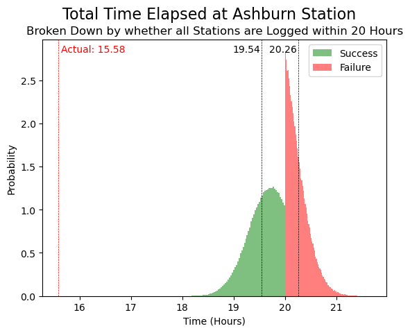

```python
success = dataframe[dataframe['trip_time']<=20]['trip_time']
failure = dataframe[dataframe['trip_time']>20]['trip_time']

plt.hist(success, density=True, bins=100,
         label='Success', color='green', alpha=0.5)
plt.hist(failure, density=True, bins=100,
         label='Failure', color='red', alpha=0.5)

plt.suptitle('Total Time Elapsed at Ashburn Station', fontsize=16)
plt.title('Broken Down by whether all Stations are Logged within 20 Hours')
plt.legend(loc='upper right')
plt.xlabel('Time (Hours)')
plt.ylabel('Probability')

plt.axvline(success.mean(), color='k', linestyle='dashed', linewidth=0.5)
plt.axvline(failure.mean(), color='k', linestyle='dashed', linewidth=0.5)
min_ylim, max_ylim = plt.ylim()
plt.text(success.mean()-0.55, max_ylim*0.95, str(round(success.mean(), 2)))
plt.text(failure.mean()-0.57, max_ylim*0.95, str(round(failure.mean(), 2)))

# Post-Attempt Numbers
plt.axvline(15+35/60, color='r', linestyle='dashed', linewidth=0.5)
plt.text(15+35/60+0.05, max_ylim*0.95, 'Actual: ' + str(round(15+35/60, 2)), color='r')
```